# Lista de Exercícios 5

### Superfície de Energia Potencial da bALA obtida no Exercício 7.2 (lista 4)

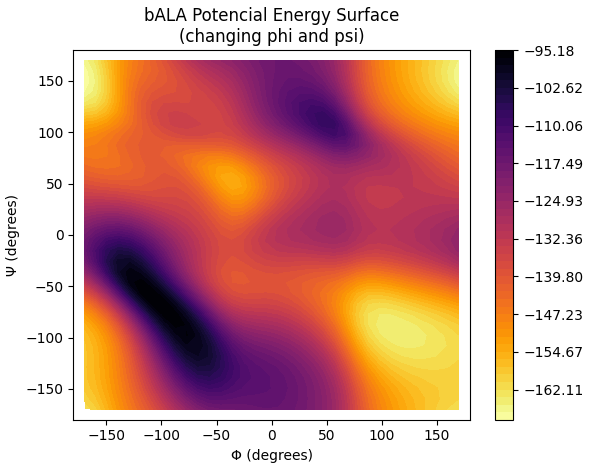

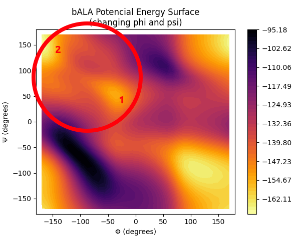

### Para a conformação alfa, os ângulo se mantiveram próximos da região de mínimo 1, não passando pelo ponto de sela, para atingir a região 2.

### Já para a conformação c7eq e c7ax, percebemos que os ângulos diedrais permaneceram na região de mínimo 2.

### A conformação c5, podemos ver que os ângulo diedrais passaram por ambas as regiões 1 e 2.

### Destarte, é clara a relação entre a Superfície de Energia Potencial e as reigões exploradas pelos ângulos diedrais na dinâmica molecular.

# ============================================================

# Ex. 3

### A tabela fornecida no arquivo coords.csv contém a evolução temporal dos valores do ângulo θ entre os átomos Cα–Cβ–Cγ do resíduo ASP-1, e dos ângulos diedrais φ e ψ do resíduo GLY-29 de uma trajetória de 55 ns de simulação de dinâmica molecular da proteína Cdc25B (PDB ID 1QB0). Usando 90 intervalos entre os valores de -180º e 180º , obtenha os seguintes gráficos para o ângulo θ e para os dois diedrais de GLY-29:

## (a) Histograma dos valores;

```python
coords = pd.read_csv("coords.csv")
coords.columns = [name.strip().lower() for name in coords.columns]
coords
```

|  | tempo(ps) | angulo | phi glu-4 | psi glu-4 | phi gly-29 | psi gly-29 |
| --- | --- | --- | --- | --- | --- | --- |
| 0 | 0 | 111.351 | -109.8440 | 104.3960 | 122.2950 | 23.688100 |
| 1 | 10 | 105.937 | -102.0600 | 80.2825 | 119.3120 | 30.283600 |
| 2 | 20 | 115.716 | -83.8672 | 99.5959 | 126.4780 | 6.347290 |
| 3 | 30 | 111.307 | -77.1193 | 102.9020 | 115.5830 | 24.276500 |
| 4 | 40 | 110.597 | -105.8150 | 79.9560 | 79.3629 | 11.500000 |
| ... | ... | ... | ... | ... | ... | ... |
| 5495 | 54950 | 113.387 | -80.8259 | 119.8810 | 102.9660 | 13.147000 |
| 5496 | 54960 | 113.441 | -69.2919 | 127.5550 | 93.1253 | 42.951800 |
| 5497 | 54970 | 115.362 | -66.0895 | 124.5540 | 83.6409 | 16.492000 |
| 5498 | 54980 | 118.518 | -71.6061 | 139.7810 | 117.3300 | 0.186288 |
| 5499 | 54990 | 118.295 | -83.1431 | 147.6240 | 116.4680 | -2.631360 |

5500 rows × 6 columns

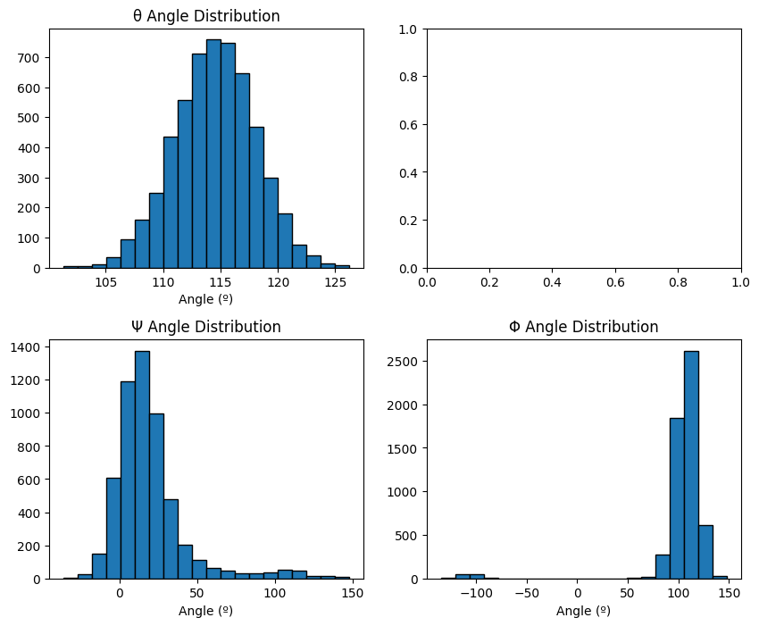

```python
fig, axs = plt.subplots(2, 2, figsize=(10, 8))

# ploting angle dist
axs[0][0].hist(coords["angulo"], bins=20, edgecolor='k')
axs[0][0].set_title("θ Angle Distribution")
axs[0][0].set_xlabel("Angle (º)")

# ploting phi gly-29 dist
axs[1][1].hist(coords["phi gly-29"], bins=20, edgecolor='k')
axs[1][1].set_title("Φ Angle Distribution")
axs[1][1].set_xlabel("Angle (º)")

# ploting angle dist
axs[1][0].hist(coords["psi gly-29"], bins=20, edgecolor='k')
axs[1][0].set_title("Ψ Angle Distribution")
axs[1][0].set_xlabel("Angle (º)")

plt.subplots_adjust(hspace=.3)
plt.show()
```

### Podemos observar que o ângulo θ possui uma distribuição mais próxima da normalidade, e teve média de 114,5º.

### Para p ângulo Ψ, observamos uma média de 19.4º, enquanto Φ teve a média de 103,2º. Como os dois ângulos diedrais são relacionados, vemos sua interdependência no gráfico, devido à presença de um gap.

## (b) A correspondente densidade de probabilidade normalizada, ρ. Explique como você calculou esta ρ;

```python
def draw_norm_dens(data, ax):
    sigma = data.std()
    mu = data.mean()

    n, bins, patches = ax.hist(data,
                               bins=20,
                               edgecolor='k',
                               density=True)

    y = ((1 / (np.sqrt(2 * np.pi) * sigma)) *
         np.exp(-0.5 * (1 / sigma * (bins - mu))**2))

    ax.plot(bins, y, '--')
```

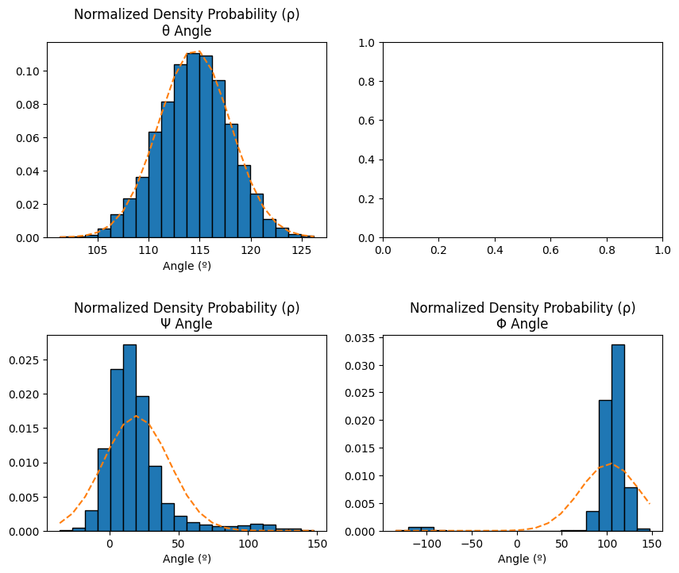

```python
fig, axs = plt.subplots(2, 2, figsize=(10, 8))

# angulo
draw_norm_dens(coords["angulo"], axs[0][0])
axs[0][0].set_title("Normalized Density Probability (ρ)\nθ Angle")
axs[0][0].set_xlabel("Angle (º)")

# phi
draw_norm_dens(coords["phi gly-29"], axs[1][1])
axs[1][1].set_title("Normalized Density Probability (ρ)\nΦ Angle")
axs[1][1].set_xlabel("Angle (º)")

# psi
draw_norm_dens(coords["psi gly-29"], axs[1][0])
axs[1][0].set_title("Normalized Density Probability (ρ)\nΨ Angle")
axs[1][0].set_xlabel("Angle (º)")

plt.subplots_adjust(hspace=.5)
plt.show()
```

## (c) Qual é a forma da ρ(θ)? Lembre-se da função de energia potencial para ângulos de ligações(harmônica) e explique porque ρ(θ) tem essa forma.

### Como podemos observar, a forma da distribuição ρ(θ) é a mais próxima de uma curva normal.

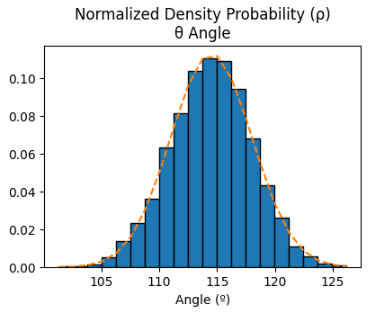

### A função de energia potencial para os ângulos de ligação é uma função harmônica simples.

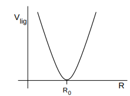

### Desta maneira, percebemos que a função de energia potencial tem uma região de mínimo, onde o ângulo θ será mais provável na dinâmica. À medida que esse ângulo aumenta ou diminui, a probabilidade de encontrados essa geometria na dinâmica também diminui exponencialmente. Podemos observar esse comportamento na distribuição ρ(θ).

## (d) Repita o item a) para θ e para ψ, mas use apenas a primeira metade da trajetória (até 22500 ps). Compare com os dois gráficos obtidos em a) e comente o caráter dinâmico da simulação. Ilustre com gráficos do valor (trajetória) dos ângulos contra o tempo. Comente a diferença qualitativa da amostragem para os dois ângulos;

### É pedido para se analisar a metade da trajetória, e no exercício ela é dita como até 22500 ps. Porém, na prática, a trajetória vai até 55000 ps, tendo a sua metade em 27500 ps. Portanto, utilizamos 27500 ps em nossas análises.

```python
coords_half = coords[coords["tempo(ps)"] < 27500]

print(coords.shape)
print(coords_half.shape)
```

```
(5500, 6)
(2750, 6)
```

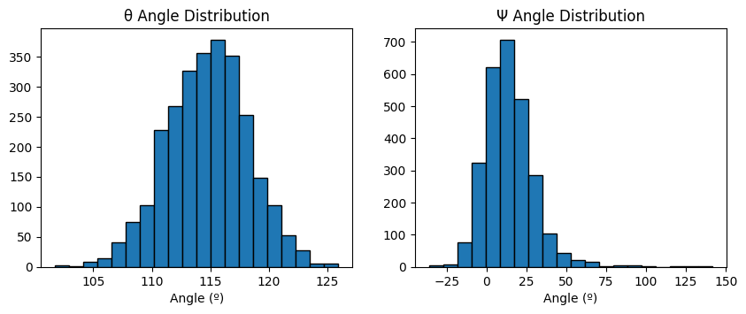

```python
fig, axs = plt.subplots(1, 2, figsize=(10, 3.5))

# ploting angle dist
axs[0].hist(coords_half["angulo"], bins=20, edgecolor='k')
axs[0].set_title("θ Angle Distribution")
axs[0].set_xlabel("Angle (º)")

# ploting angle dist
axs[1].hist(coords_half["psi gly-29"], bins=20, edgecolor='k')
axs[1].set_title("Ψ Angle Distribution")
axs[1].set_xlabel("Angle (º)")

plt.subplots_adjust(hspace=.3)
plt.show()
```

### Gráficos resultantes do exercício a:

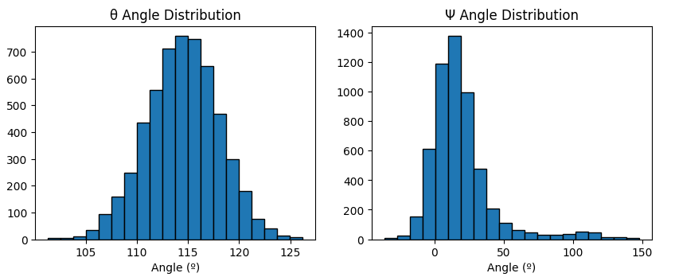

### Em relação ao gráfico do ângulo θ, podemos perceber que os histogramas são semelhantes. Porém, a distribuiçao com o tempo inteiro da simulação apresenta-se visualmente mais próxima de uma curva normal.

### Em relação ao gráfico do ângulo Ψ, a pesar dos gráficos também serem semelhante, podemos observar uma cauda mais significativa na distribuição feita com o tempo inteira da simulação. Percebemos como, ao aumentar o tempo de simulação, geometrias mais raras têm mais oportunidades de aparecer, causando o fenômeno descrito.

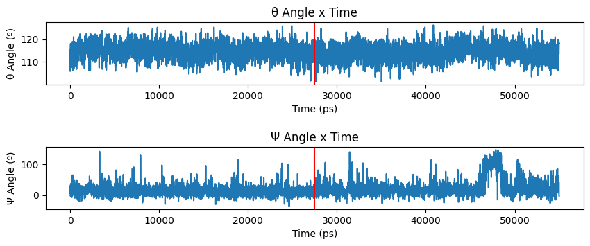

```python
fig, axs = plt.subplots(2, 1, figsize=(10, 3.5))

# ploting angle
axs[0].plot(coords["tempo(ps)"], coords["angulo"])
axs[0].set_title("θ Angle x Time")
axs[0].set_ylabel("θ Angle (º)")
axs[0].set_xlabel("Time (ps)")
axs[0].axvline(x=27500, color='r')

# ploting psi angle
axs[1].plot(coords["tempo(ps)"], coords["psi gly-29"])
axs[1].set_title("Ψ Angle x Time")
axs[1].set_ylabel("Ψ Angle (º)")
axs[1].set_xlabel("Time (ps)")
axs[1].axvline(x=27500, color='r')

plt.subplots_adjust(hspace=1)
plt.show()
```

### Pela escala do eixo y, podemos ver como o ângulo Ψ variou muito mais do que o ângulo θ.

### Para o ângulo θ, não há diferença notável entre as duas metades da simulação.

### Para o ângulo Ψ, a simulação se mostrou próxima de 20º na maior parte do tempo, porém houve um período no qual os ângulos permaneceram próximo de 100º, na segunda metade da simulação.

## (e) Desenhe um gráfico de Ramachandran para o resíduo GLY-29 com os dados da tabela e responda:

## i. Os diedrais são estatisticamente correlacionados? Porque? Qual a explicação física ou estrutural?

## ii. Compare o gráfico de Ramachandran com os gráficos projetados obtidos na parte a). Que informação é perdida neste processo de projeção?

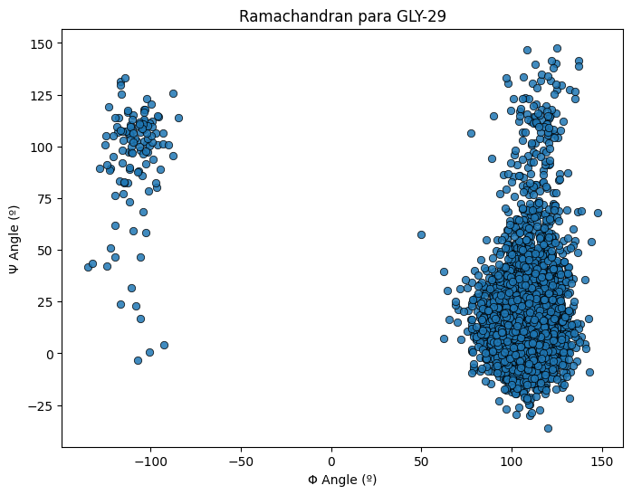

```python
fig, ax = plt.subplots(1, 1, figsize=(8,6))


ax.scatter(coords["phi gly-29"],
           coords["psi gly-29"],
           edgecolors='k',
           alpha=0.85,
           linewidths=0.6)

ax.set_title("Ramachandran para GLY-29")
ax.set_xlabel("Φ Angle (º)")
ax.set_ylabel("Ψ Angle (º)")

plt.show()
```

### i. Podemos observar que os diedrais estão estatisticamente relacionados. De um ponto de vista físico, esta observação faz bastante sentido, posto que a posição de um diedral influencia na posição de outro, por conta de interações não ligantes.

### ii. Podemos observar abaixo os gráficos gerados no exercício a para os ângulos Φ e Ψ. No gráfico de Ramachandran, é mais fácil de observar a correlação entre os dois diedrais, porém é mais difícil acessar a informação de frequência de cada ângulo.

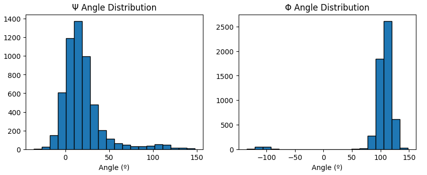

### Abaixo, mostramos um gráfico de histograma 2D, onde é possível observar melhor tanto a correlação entre os dois ângulos diedrais, quanto a frequência de cada um, aproximando-se mais de um gráfico de Ramachandran usual.

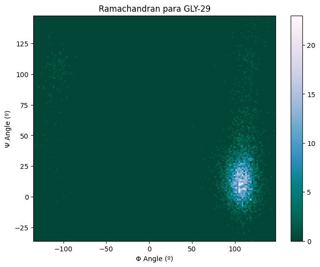

```python
fig, ax = plt.subplots(1, 1, figsize=(8,6))


h = ax.hist2d(coords["phi gly-29"],
          coords["psi gly-29"],
          bins=150,
          cmap=plt.cm.PuBuGn_r)

ax.set_title("Ramachandran para GLY-29")
ax.set_xlabel("Φ Angle (º)")
ax.set_ylabel("Ψ Angle (º)")

fig.colorbar(h[3], ax=ax)

plt.show()
```

## (f) Calcule a média e a variância para os ângulos θ, Φ e ψ dados. As distribuições são uni- ou multimodais? A variância de cada distribuição é grande ou pequena?

```python
coords_summary = coords[["angulo", "phi gly-29", "psi gly-29"]].describe()
coords_summary.loc["var"] = [coords["angulo"].var(), coords["phi gly-29"].var(), coords["psi gly-29"].var()]
coords_summary.loc[["count", "mean", "std", "var"]]
```

|  | angulo | phi gly-29 | psi gly-29 |
| --- | --- | --- | --- |
| count | 5500.000000 | 5500.000000 | 5500.000000 |
| mean | 114.509466 | 103.175579 | 19.397363 |
| std | 3.528807 | 32.737277 | 23.746456 |
| var | 12.452480 | 1071.729336 | 563.894179 |

### Pelos histogramas plotados no exercício a, podemos observar que os ângulos θ e ψ são unimodais, enquanto o ângulo Φ apresenta distribuição bimodal.

### Esta informação também pode ser observada ao se projetar os pontos nos eixos x e y do gráfico de Ramachandran.

### A distribuição do ângulo θ é pequena, representa apenas 11% da média.

### As distribuições dos ângulos Φ e ψ são grandes, representando 1038% e 2907%, respectivamente